# compile-regional-data

#### Chum

Fraser chum catch and escapement are reported by PSC’s Chum Technical Committee (Chum Technical Committee 2023), and were provided to us on request to Brittany Jenewin (DFO, pers. comm.). For 2023 and 2024, estimates were extracted from the [Fraser Management Council post-season review](https://frasersalmon.ca/wp-content/uploads/2025/01/2024-Fraser-Coho-and-Chum-Post-season-Review-2025-01-28-FINAL-1.pdf).

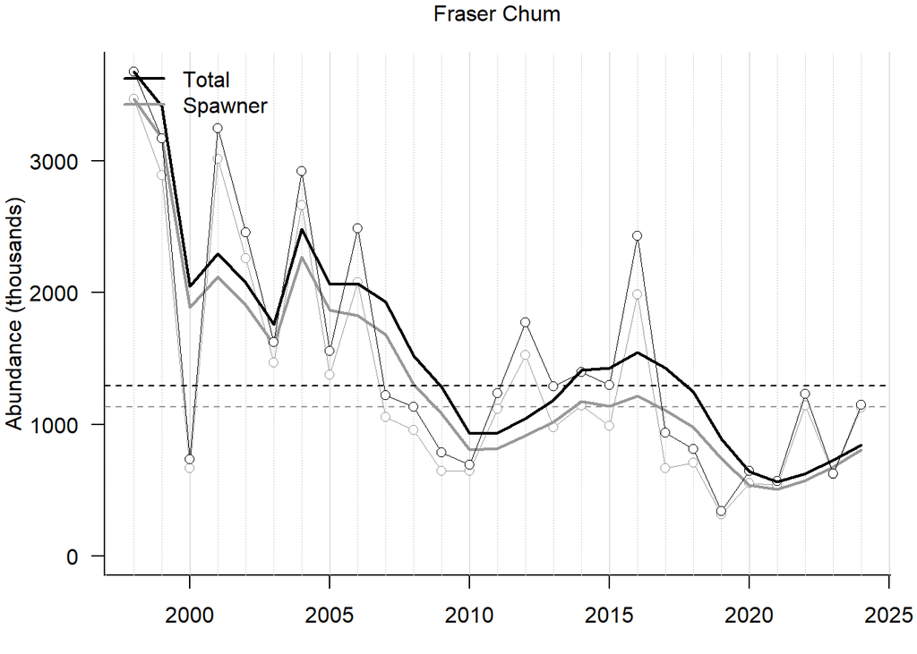

**Above:**Spawner abundance (grey) and total abundance (black) of Fraser Chum salmon. For both, the raw data is shown by points and the smoothed metric by solid lines. Dashed horizonal lines represent the long-term average for each.

#### Coho

For interior Fraser coho CUs, spawner abundance and total return to 2022 were provided by DFO on data request (pers. comm. Marissa Glavas, Data Manager, Fraser River Stock Assessment). We report total return as the sum of “Total Pre-Fishery Abundance” to all CUs and spawner abundance as the sum of “Total Return” (i.e., final spawner estimate plus fish removed from the system by DFO Salmon Enhancement Program or First Nations) to all CUs (we note the term “total return” is used differently in this data set to represent spawners!). We recognize that using these estimates ignores coastal coho populations, for which monitoring has been patchy through time. Spawner and run size for 2023 and preliminary spawner abundance for 2024 were taken from the presentation of [2025/26 Southern B.C. Salmon: Chum and Coho](https://frasersalmon.ca/wp-content/uploads/2025/02/2025-Forum-2_Richmond_Chum-and-Coho.pdf) dated February 2025. Preliminary 2024 spawner abundance is for natural-origin spawners only, and is a lower estimate of the total 2024 spawner abundance. However, the numbers of hatchery-origin spawners have been low (< 10%) over the past two decades.

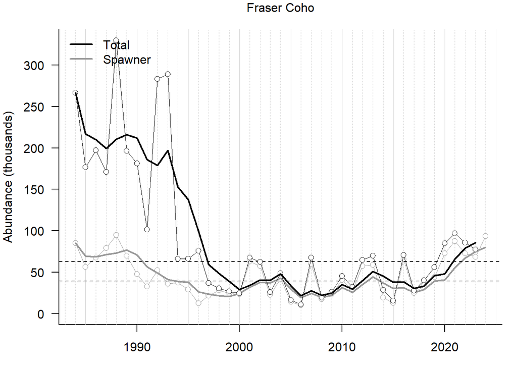

**Above:**Spawner abundance (grey) and total abundance (black) of Fraser coho salmon. For both, the raw data is shown by points and the smoothed metric by solid lines. Dashed horizonal lines represent the long-term average for each.

```r
## Load data ---
frco <- read.csv("../data/IFC_data_compiled.csv")
# Put in SPS format
frco_sps <- data.frame(
    region = rep("Fraser", length(frco$year)),
    species = rep("Coho", length(frco$year)),
    year = frco$year,
    spawners = frco$spawners, # Note this is the fish that returned to spawn, NOT a mistake!
    smoothedSpawners = NA,
    runsize = frco$runsize,
    smoothedRunsize = NA,
    source_id = c(rep("Glavas_20231006", length(frco$year) - 2), rep("DFO_20250225", 2))
)

# Smoothing
frco_sps$smoothedSpawners <- genSmooth(
    abund = frco_sps$spawners,
    years = frco_sps$year,
    genLength = genLength$gen_length[genLength$region == "Fraser" & genLength$species == "Coho"]
)

frco_sps$smoothedRunsize <- genSmooth(
    abund = frco_sps$runsize,
    years = frco_sps$year,
    genLength = genLength$gen_length[genLength$region == "Fraser" & genLength$species == "Coho"]
)

# Add to master sps dataframe
sps_data <- rbind(sps_data, frco_sps)

# Generate standard figure
plot_abund(frco_sps)
```

#### Pink and Sockeye

Data on total return and spawner abundance of pink salmon and sockeye salmon in the Fraser region are provided by the PSC and accessed through the Fraser Panel Annual Report: Data Application (Pacific Salmon Commission 2024). Total escapement for Fraser sockeye was not yet available for 2023, and 2023 total return is considered preliminary. We note that Fraser River pink salmon are only counted in the dominant, odd-year run.

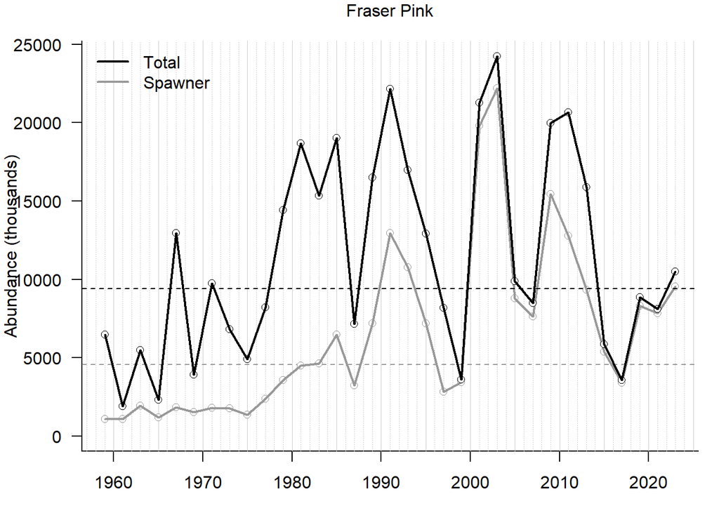

**Above:**Spawner abundance (grey) and total abundance (black) of Fraser pink salmon. For both, the raw data is shown by points and the smoothed metric by solid lines. Dashed horizonal lines represent the long-term average for each.

```r
## Load data ---
# Note: Only odd year data, so no change 2024 -> 2025 (data still to 2023)
# From PSC
frpk <- read.csv("../data/pink_run_size_2025-04-24.csv") # No changes from Apr 24, 2025 version to Sept 18, 2025, but cite Sept because fraser sockeye in-season estimate for 2024 DID change (and don't want to change that number at this point)

# Put in SPS format
frpk_sps <- data.frame(
    region = rep("Fraser", length(frpk$Year)),
    species = rep("Pink", length(frpk$Year)),
    year = frpk$Year,
    spawners = frpk$Escapement, # Note this is the fish that returned to spawn, NOT a mistake!
    smoothedSpawners = NA,
    runsize = frpk$Run.Size,
    smoothedRunsize = NA,
    source_id = rep("PSC_20250424", length(frpk$Year))
)

# Smoothing - don't do this for pink salmon in the Fraser - no even year data!
frpk_sps$smoothedSpawners <- frpk_sps$spawners
frpk_sps$smoothedRunsize <- frpk_sps$runsize

# Add to master sps dataframe
sps_data <- rbind(sps_data, frpk_sps)

#Generate standard figure
plot_abund(frpk_sps)
```

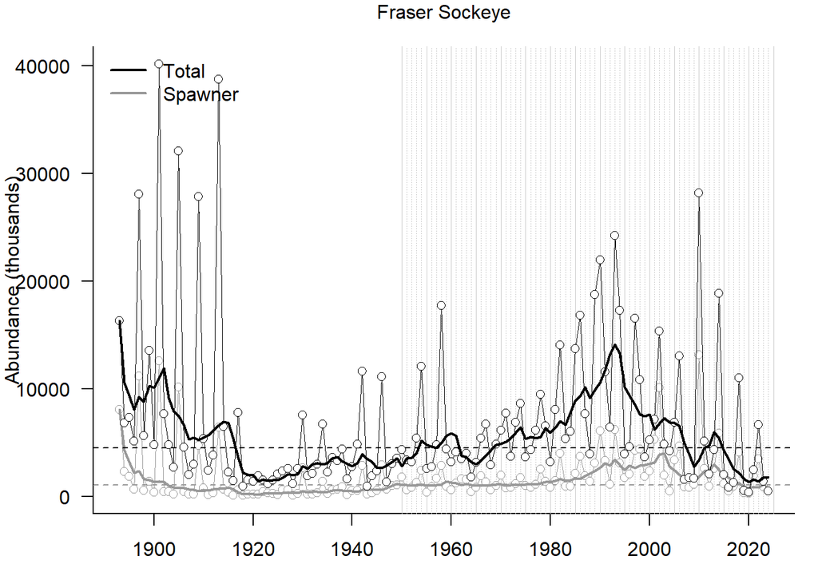

**Above:**Spawner abundance (grey) and total abundance (black) of Fraser sockeye salmon. For both, the raw data is shown by points and the smoothed metric by solid lines. Dashed horizonal lines represent the long-term average for each.

```r
## Load data ---
# From PSC
frse <- read.csv("../data/Fraser Sockeye Run Size_2025-04-24.csv") %>%
    filter(Management.Group == "Total Fraser")

# Put in SPS format
frse_sps <- data.frame(
    region = rep("Fraser", length(frse$Year)),
    species = rep("Sockeye", length(frse$Year)),
    year = frse$Year,
    spawners = frse$Spawning.Escapement, # Note this is the fish that returned to spawn, NOT a mistake!
    smoothedSpawners = NA,
    runsize = frse$Run.Size,
    smoothedRunsize = NA,
    source_id = rep("PSC_20250424", length(frse$Year))
)

# Fill in run size with in-season estimates if available
if(sum(is.na(frse_sps$runsize)) > 0){
    if(sum(!is.na(frse$In.season.Run.Size[which(frse$Year %in% frse_sps$year[is.na(frse_sps$runsize)])])) > 0){
        frse_sps$runsize[which(frse$Year %in% frse_sps$year[is.na(frse_sps$runsize)])] <- frse$In.season.Run.Size[which(frse$Year %in% frse_sps$year[is.na(frse_sps$runsize)])]
    }
}

# Smoothing
frse_sps$smoothedSpawners <- genSmooth(
    abund = frse_sps$spawners,
    years = frse_sps$year,
    genLength = genLength$gen_length[genLength$region == "Fraser" & genLength$species == "Sockeye"]
)

frse_sps$smoothedRunsize <- genSmooth(
    abund = frse_sps$runsize,
    years = frse_sps$year,
    genLength = genLength$gen_length[genLength$region == "Fraser" & genLength$species == "Sockeye"]
)

# Add to master sps dataframe
sps_data <- rbind(sps_data, frse_sps)

# Generate standard figure
# plot_abund(frse_sps[frse$Year >= 1980,]); abline(v = 2024)
plot_abund(frse_sps)
```

#### Steelhead

Steelhead trout in the Fraser are monitored by the Province in at least 10 different streams, but these data are not readily available. Relatively reliable estimates of steelhead spawner abundance are available at the CU-level for interior Fraser steelhead from the Thompson Summer CU (monitored at the Thompson River) and Mid Fraser Summer CU (primarily monitored at the Chilcotin River; data in the [Pacific Salmon Explorer](https://salmonexplorer.ca)). We used the sum of CU-level spawner abundance for these two CUs as an index of Fraser steelhead abundance. We note that this approach does not include more coastal populations, such as the Lower Fraser Summer steelhead monitored in the Coquihalla River or Boundary Bay Winter steelhead, which may not have declined to the same extent over the past decade. However, a lack of publicly accessible data on coastal Fraser steelhead has limited our ability to include these CUs in our index of abundance.

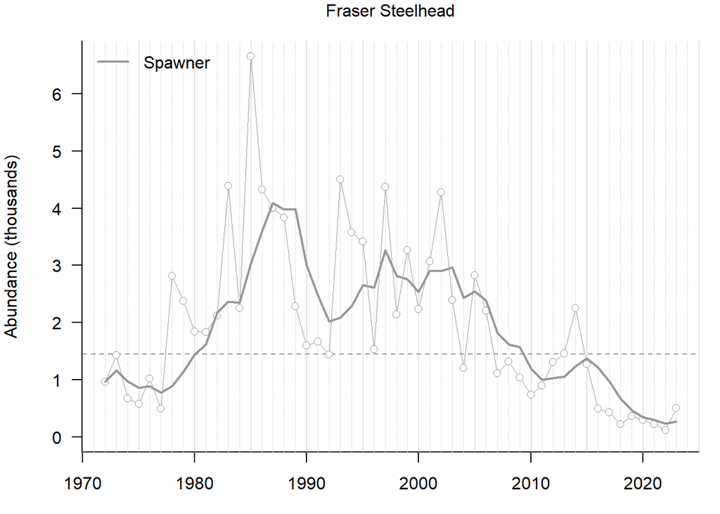

**Above:**Spawner abundance of Fraser steelhead salmon. The raw data is shown by points and the smoothed metric by solid lines. Dashed horizonal lines represent the long-term average.

```r
## Load data ---
# Use sum of two main Fraser steelhead CUs
frsh <- read.csv("../data/dataset1cu_steelhead_20250117.csv") %>%
    filter(region == "Fraser", species_name == "Steelhead") %>%
    filter(cu_name_pse %in% c("Thompson Summer", "Mid Fraser Summer")) %>%
    filter(!is.na(estimated_count) & estimated_count != -989898)

frsh_sum <- tapply(as.numeric(frsh$estimated_count), frsh$year, sum)
frsh_sum <- frsh_sum[min(which(!is.na(frsh_sum))): max(which(!is.na(frsh_sum)))]

# Put in SPS format
frsh_sps <- data.frame(
    region = rep("Fraser", length(frsh_sum)),
    species = rep("Steelhead", length(frsh_sum)),
    year = as.numeric(names(frsh_sum)),
    spawners = frsh_sum, # Note this is the fish that returned to spawn, NOT a mistake!
    smoothedSpawners = NA,
    runsize = NA,
    smoothedRunsize = NA,
    source_id = rep("Bison_20241129", length(frsh_sum))
)

# Smoothing
frsh_sps$smoothedSpawners <- genSmooth(
    abund = frsh_sps$spawners,
    years = frsh_sps$year,
    genLength = genLength$gen_length[genLength$region == "Fraser" & genLength$species == "Steelhead"]
)

# Add to master sps dataframe
sps_data <- rbind(sps_data, frsh_sps)

# Generate standard figure
plot_abund(frsh_sps)
```

### 2.2.10 Columbia

#### Chinook

We used CU-level estimates of spawner abundance (run reconstructions) sourced from DFO (Athena Ogden, pers. comm.) for Chinook and sockeye.

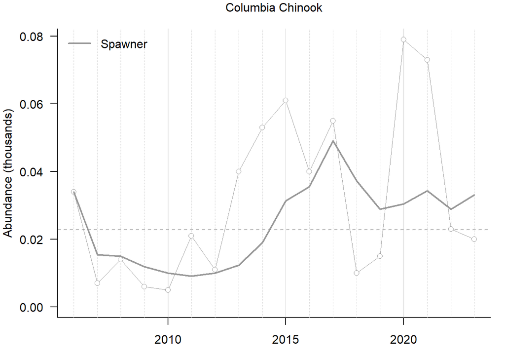

**Above:**Spawner abundance of Columbia chinook salmon. The raw data is shown by points and the smoothed metric by solid lines. Dashed horizonal lines represent the long-term average.

```r
colck <- read.csv("../data/Chinook_Okanagan_NEW.csv") %>% filter(Year >= 2006)
# Downloaded from https://github.com/SOLV-Code/Scanner-Data-Processing/blame/main/DATA_IN/Chinook_Okanagan_NEW.csv
# on March 18, 2025

# Put in SPS format
colck_sps <- data.frame(
    region = rep("Columbia", length(colck$Year)),
    species = rep("Chinook", length(colck$Year)),
    year = colck$Year,
    spawners = as.numeric(colck$NatOrigSpn + colck$HatchOrigSpn), # Note this is the fish that returned to spawn, NOT a mistake!
    smoothedSpawners = NA,
    runsize = NA,
    smoothedRunsize = NA,
    source_id = rep("DFO_20250318", length(colck$Year))
)

# Smoothing
colck_sps$smoothedSpawners <- genSmooth(
    abund = colck_sps$spawners,
    years = colck_sps$year,
    genLength = genLength$gen_length[genLength$region == "Columbia" & genLength$species == "Chinook"]
)

# Add to master sps dataframe
sps_data <- rbind(sps_data, colck_sps)

# Generate standard figure
plot_abund(colck_sps)
```

#### Sockeye

We used CU-level estimates of spawner abundance (run reconstructions) sourced from DFO (Athena Ogden, pers. comm.) for Chinook and sockeye. Spawner abundance for Columbia sockeye was the sum of estimates for Osoyoos and, more recently, Skaha Lakes and were the most up-to-date estimates as of June 2025 (Athena Ogden, pers. comm.). Total abundance for sockeye was extracted from DFO’s 2024 Wild Salmon Policy assessment for Osoyoos sockeye (DFO 2024) from 1980-2023.

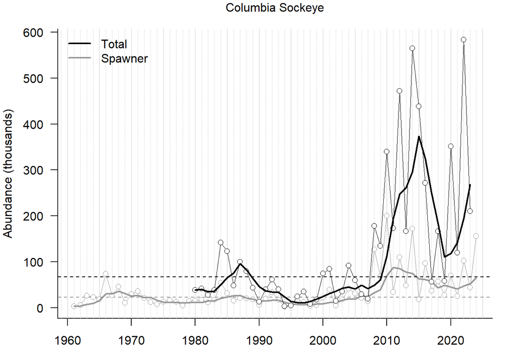

**Above:**Spawner abundance (grey) and total abundance (black) of Columbia sockeye salmon. For both, the raw data is shown by points and the smoothed metric by solid lines. Dashed horizonal lines represent the long-term average for each.

```r
# Load data ---
colse_old <- read.csv("../data/spawner_abundance.csv") %>%
    subset(region == "Columbia" &  species_name == "Lake sockeye") %>%
    subset(!is.na(estimated_count))

colse <- read.csv("../data/OkanaganSockeye.csv")

colse2 <- readxl::read_xlsx("../data/Okanagan Sockeye Esc for KR_revJn2025.xlsx", sheet = "CAN Escapement", range = "A1:E65")

# Put in SPS format
yrs <- sort(colse2$Year) # don't use pre-2004 (not comparable; DFO 2024)
colse_sps <- data.frame(
    region = rep("Columbia", length(yrs)),
    species = rep("Sockeye", length(yrs)),
    year = yrs,
    spawners = round(colse2$`Total spawners`[match(yrs, colse2$Year)]),
    smoothedSpawners = NA,
    runsize = colse$runsize[match(yrs, colse$year)],
    smoothedRunsize = NA,
    source_id = c(rep("Ogden_20250627, Ogden_20250901", length(yrs) - 1), "Ogden_20250627")
)

# Smoothing
colse_sps$smoothedSpawners <- genSmooth(
    abund = colse_sps$spawners,
    years = colse_sps$year,
    genLength = genLength$gen_length[genLength$region == "Columbia" & genLength$species == "Sockeye"]
)
colse_sps$smoothedRunsize <- genSmooth(
    abund = colse_sps$runsize,
    years = colse_sps$year,
    genLength = genLength$gen_length[genLength$region == "Columbia" & genLength$species == "Sockeye"]
)


# Add to master sps dataframe
sps_data <- rbind(sps_data, colse_sps)

# Generate standard figure
plot_abund(colse_sps)
```

#### Steelhead

There is no monitoring of steelhead trout in the Canadian portion of the Columbia region, but the Okanagan Nation Alliance does enumerate steelhead in akskwəkwant (Inkaneep Creek) and estimate a Canadian portion of steelhead spawning abundance. These data can be found in associated report (e.g. OBMEP (2025)) and are available for the Mid Columbia Summer Conservation Unit [in the Pacific Salmon Explorer](https://salmonexplorer.ca/explore/data/spawner-abundance/columbia/steelhead/mid-columbia-summer-1380/).

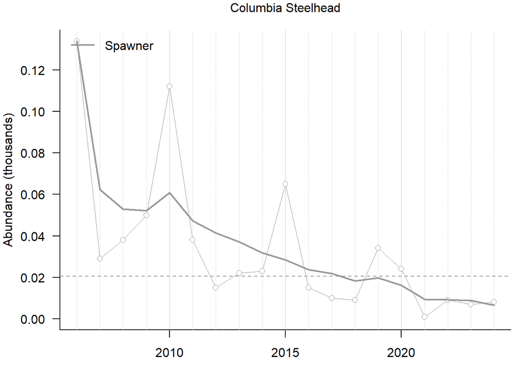

**Above:**Spawner abundance of Columbia steelhead salmon. The raw data is shown by points and the smoothed metric by solid lines. Dashed horizonal lines represent the long-term average.

```r
colsh <- read.csv("../data/Columbia_Steelhead_OBMEP.csv")

# Put in SPS format
colsh_sps <- data.frame(
    region = rep("Columbia", length(colsh$year)),
    species = rep("Steelhead", length(colsh$year)),
    year = colsh$year,
    spawners = colsh$natural_spawners, # Note this is the fish that returned to spawn, NOT a mistake!
    smoothedSpawners = NA,
    runsize = NA,
    smoothedRunsize = NA,
    source_id = rep("OBMEP_20250228", length(colsh$year))
)

# Smoothing
colsh_sps$smoothedSpawners <- genSmooth(
    abund = colsh_sps$spawners,
    years = colsh_sps$year,
    genLength = genLength$gen_length[genLength$region == "Columbia" & genLength$species == "Steelhead"]
)


# Add to master sps dataframe
sps_data <- rbind(sps_data, colsh_sps)

# Generate standard figure
plot_abund(colsh_sps)
```

```r
#write.csv(sps_data, "output/sps-data.csv", row.names = FALSE) # Always have most recent # Not until this script is confirmed to be working
write.csv(sps_data, paste0("../output/archive/sps-data_", Sys.Date(), ".csv"), row.names = FALSE) # Archive with date
```

## 2.3 Expansion Factors

For species and regions that lacked reliable data on spawner abundance and total return at the appropriate scale, we estimated regional-scale abundance from stream-level surveys. We started with spawner survey data shown in the [Pacific Salmon Explorer](https://www.salmonexplorer.ca). Spawner surveys were each assigned to one of the nine regions we considered based on their geographic location. We note that this is slightly different from how spawner survey data are organized in the Pacific Salmon Explorer, where data are organized by Conservation Units (CUs) that may span regional boundaries (e.g. for pink salmon that have relatively geographically large CUs). In cases of trans-regional CUs, the spawner surveys appear in both regions in the Pacific Salmon Explorer, whereas here we assign spawner surveys to the region in which they fall geographically, regardless of the CU boundary.

Spawner survey data are largely derived from river-level estimates in DFO’s [New Salmon Escapement Database System (NuSEDS)](https://open.canada.ca/data/en/dataset/c48669a3-045b-400d-b730-48aafe8c5ee6), but are cleaned up to address issues of, for example, inconsistent naming of streams through time or duplicate data. The spawner survey abundance is equal to the `MAX_ESTIMATE` in NUSEDS for each year and river population, calculated as the maximum of all fields containing spawner abundance data (e.g. natural adult spawners, natural jack spawners, total broodstock removals). Each of these river populations has been designated as an **indicator** stream or **non-indicator**. Indicator streams are observed more consistently in recent decades, tend to have higher spawner abundance, and tend to be monitored using more intensive methods that provide greater accuracy (English et al. 2018). For further information on the compilation of spawner survey data, see the [Pacific Salmon Explorer Technical Report](https://bookdown.org/salmonwatersheds/tech-report/analytical-approach.html#spawner-surveys).

Expansion Factor 1, $F_{1,y/d}$, expands the observed spawner abundances in indicator streams to account for indicator streams that are not monitored in a given year. It is calculated for each year $y$ of the spawner time series, and relies on a decadal contribution of each indicator stream to the total escapement to all indicator streams, $P_{d,i}$ in decade $d$ (English et al. 2018). The calculation of this decadal contribution requires at least one estimate from each indicator stream for the decade. If a decade does not contain sufficient information (i.e. one or more indicator streams are not monitored at all in a decade), then a reference decade is used to calculate $P_{d,i}$. This reference decade is chosen to be: (1) the closest decade (historical or future) with sufficient information, or failing (1), (2) the 20-year period from 1980-1999 (Challenger et al. 2018).

For each decade (or reference decade if insufficient information) $d$, the average number of spawners returning to indicator stream $i$ is calculated as:

$$\bar{S}_{d,i} = \sum_{y = 1}^{Y_{d,i}}
\frac{\hat{S}_{y/d, i}}{Y_{d,i}}$$
where $Y_{d,i}$ is the number of years for which spawner estimates are available within decade $d$ for stream $i$. From the average number of spawners for all indicator streams, the decadal proportional contribution of each indicator stream is calculated as:

$$P_{d,i} =
\frac{\bar{S}_{d,i}}{\sum_{i=1}^{I} \bar{S}_{d,i}}$$
where $I$ is the total number of indicator streams.

Expansion Factor 1 is then calculated for each year within the decade $y/d$ based on the decadal contributions and which streams were monitored or not in a given year:

$$F_{1,y/d}=\left( \sum_{i=1}^I P_{d,i}
w_{y/d,i} \right)$$
where $w_{y/d,i}$ is 1 if stream $i$ was monitored in year $y$ and 0 if stream $i$ was not monitored in year $y$. Expansion Factor 1 is then multiplied by the sum of the observed spawners in all indicator stream to yield the expanded estimate of spawner abundances in all indicator streams in the region:

$$S'_{y} = F_{1,y/d} \sum_{i=1}^I
\hat{S}_{y,i}$$

Expansion Factor 2 $F_{2,d}$ expands the spawner abundance to all indicator streams, $S'_{y}$, to account for non-indcator streams. Unlike Expansion Factor 1, this is calculated for each decade (rather than each year) and then applied to all years within a decade. Like Expansion Factor 1, there needs to be sufficient information within the given decade in order to calculate $F_{2,d}$, or else a reference decade is chosen. See English et al. (2018) for detailed on how reference decades are chosen in that case.

Expansion Factor 2 is calculated as:

$$F_{2,d} = \frac{\sum_{i = 1}^I
\bar{S}_{d,i} + \sum_{j = 1}^{J} \bar{S}_{d,j}}{\sum_{i = 1}^I
\bar{S}_{d,i}}$$
where $\bar{S}_{d,i}$ and $\bar{S}_{d,j}$ are the deacdal average number of spawners in indicator and non-indicator streams, respectively, calculated above. $J$ is the total number of non-indicator streams. The adjusted total number of spawners in both indicator and non-indicator streams is then calculated as:
$$S''_{y} = F_{2,d} S'_{y}$$

Note that when expanding spawner abundance for spawner-recruit analysis, a third expansion factor is applied to account for streams that are never monitored and for observer (in)efficiency (Peacock et al. 2020). We did not apply this third expansion factor because it is highly undertain and we are interested in relative changes in abundance through time, so we do not require to expand to absolute abundance.

## 2.4 Smoothing

We smoothed time series of spawner abundance and total return using a right-aligned running geometric mean over the length of a generation. This reduces the influence of dominant years and produces an index that is less sensitive to stochastic interannual variability that is common in salmon population dynamics. The generation length was based on the dominant life-history type for each species in a particular region. The smoothed spawner abundance in year $y$ given a generation length $g$ was calculated as:
$$\bar{S_{y}} = \left( \prod_{t = y-g+1}^y
{S''_t} \right)^{1/g}$$

We smoothed abundance from the first year to the most recent year of raw abundance data. If there were intermediate years with missing data, the smoothed abundance was still calculated using the available years (i.e. ignoring the missing data, with the exponent $1/g$ adjusted so that $g$ reflected the number of years with data in the generation). If all years in a generation were missing data, than the smoothed abundance was `NA`.

When plotting, we show the smoothed abundance relative to the long-term historical average, so that species that have vastly different abundances within a region can be plotted on the same y-axis for comparison.

## 2.5 Quantifying change

We summarize the time series of smoothed spawner abundance or total return at the regional scale using three different metrics:

1. **Current status** relative to historical average;
2. **Long-term trend** over the entire time series; and
3. **Short-term trend** over the most recent three generations.

The currents status provides information on how the most recent spawner abundance compares to past values, while the two trend metrics provide information on the average direction of change and are less sensitive to the magnitude of current abundance.

The **current status** relative to historical average is calculated as:
$$(\bar{S_{y}} - \bf{S}) /
\bf{S}$$
where $y$ is the most recent year for which the index of spawner abundance could be calculated and $\bf{S}$ is the average smoothed spawner abundance over the entire time series.

The **long-term trend** is calculated following the recommendations of D’Eon-Eggertson et al. (2015), who found that the correct identification of declines in salmon population abundance may be most reliable when considering the entire time series, and applying regression-based estimates of change calculated from log-transformed and smoothed spawner abundances. As such, we fit a simple linear model to the time series of $\log ( \bar{S}_{y} )$ over $y$. The resulting slope, $m$, gives an average estimate of annual change:

$$m = \log \left(
\frac{\bar{S}_{y}}{\bar{S}_{y-1}} \right)$$
.

With some rearranging, we can calculate the average annual percent change as:
$$\frac{\bar{S}_{y} -
\bar{S}_{y-1}}{\bar{S}_{y-1}} = \frac{ e^m \bar{S}_{y-1} -
\bar{S}_{y-1}}{\bar{S}_{y-1}} = e^m - 1$$
. If the slope $m$ is not significantly different from zero ($p \geq 0.05$), then the trend is classified as “stable” regardless of the magnitude of the estimated slope. If the slope is significantly different from zero ($p < 0.05$), then the trend is classified as increasing if $m > 0$ or decreasing if $m < 0$.

The **short-term trend** is calculated as described above, but only using the time series over the most recent three generations.

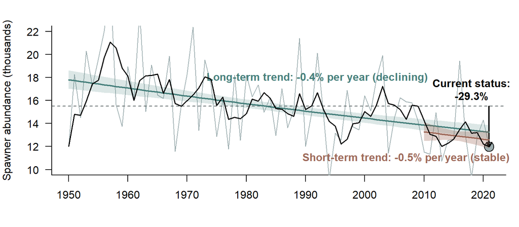

**Above:** Simulated time series of spawner abundance (grey line), smoothed with a running geometric mean over the generation length (4 years; black line). The three metrics are illustrated: **Current status** relative to historical average (black); **Long-term trend** over the entire time series (green); and **Short-term trend** over the most recent three generations (clay). The shaded regions of the regression lines indicate the 95% prediction intervals. In this example, the short-term trend is not statistically significant (p > 0.05), and so the trend is characterized as ‘stable’ despite the negative slope.

### 2.5.1 Additional Considerations

Challenger, W., Mochizuki, T., English, K., and Bychkov, Y. 2018. North and Central Coast Salmon Database and Analysis System User Manual. LGL Limited for Pacific Salmon Foundation, Sidney, BC.

Chinook Technical Committee. 2025. Annual Report of Catch and Escapement for 2024. Pacific Salmon Commission Joint Chinook Technical Committee Report **TCCHINOOK (25)-02**: xviii + 180 p. Available from https://www.psc.org/reports/tcchinook-25-02.

Chum Technical Committee. 2023. 2019 Post-Season Summary Report. Pacific Salmon Commission Joint Chum Technical Committee **TCCHUM (23)-01**: viii + 60. Available from https://www.psc.org/publications/technical-reports/technical-committee-reports/chum/.

D’Eon-Eggertson, F., Dulvy, N.K., and Peterman, R.M. 2015. Reliable Identification of Declining Populations in an Uncertain World. Conservation Letters **8**(2): 86–96. doi:10.1111/conl.12123.

DFO. 2024. Wild Salmon Policy Status, Limit Reference Point, and Candidate Escapement Goals for Okanagan Sockeye Salmon. Canadian Science Advisory Secretariat Science Advisory Report **2024/060**: 17. Available from https://publications.gc.ca/collections/collection_2025/mpo-dfo/fs70-6/Fs70-6-2024-060-eng.pdf.

DFO. 2025. West Coast of Vancouver Island Natural-Origin Chinook Salmon (Oncorhynchus tshawytscha) Stock Assessment in 2024. DFO Canadian Science Response **2025/021**. Available from https://www.dfo-mpo.gc.ca/csas-sccs/Publications/ScR-RS/2025/2025_021-eng.html.

English, K.K., Alexander, R.F., Ian A. Beveridge, Challenger, W., Percival, N., Hertz, E., and Atkinson, C. 2023. Preliminary Area 3 Salmon (2018–2022) and Nass River Summer-Run Steelhead (1994–2022) Escapement, Catch, Run Size, and Exploitation Rate Estimates. Prepared by LGL Ltd. and Nisga’a Lisims Government - Fisheries & Wildlife Department for the Pacific Salmon Foundation and Nisga’a-Canada-BC Treaty’s Joint Fisheries Management Committee. Available from https://salmonwatersheds.ca/document/lib_526/.

English, K.K., Gazey, W.J., Peacock, D., and Oliver, G. 2004. Assessment of the Canadian and Alaskan Sockeye Stocks Harvested in the Northern Boundary Fisheries using Run Reconstruction Techniques, 1982-2001. Available from https://salmonwatersheds.ca/document/lib_a_787_06/.

English, K.K., Noble, C., and Carr-Harris, C. 2017. Skeena Sockeye In-river Run Reconstruction Analysis Model and Analysis Results for 1982-2017. Report prepared for Pacific Salmon Foundation by LGL Ltd. and Fisheries and Oceans Canada. Available from https://salmonwatersheds.ca/document/lib_452/ [accessed 23 November 2023].

English, K.K., Peacock, D., Challenger, W., Noble, C., Beveridge, I., Robichaud, D., Beach, K., Hertz, E., and Connors, K. 2018. North and Central Coast Salmon Escapement, Catch, Run Size and Exploitation Rate Estimates for each Salmon Conservation Unit for 1954-2017. Report prepared by LGL Limited for the Pacific Salmon Foundation. Available from https://salmonwatersheds.ca/document/lib_451/.

Nisga’a Fisheries and Wildlife Department. 2024. 2024 Nass River Salmon Stock Assessment - Post-Season Summary.

Northern Boundary Technical Committee. 2023. U.S./Canada Northern Boundary Area 2022 Salmon Fisheries Management Report and 2023 Preliminary Expectations. Pacific Salmon Commission Joint Northern Boundary Technical Committee Report **TCNB (23)-01**: ii + 73 p. Available from https://www.psc.org/publications/technical-reports/technical-committee-reports/northern-boundary/.

OBMEP. 2025. 2024 Okanogan Subbasin Steelhead Spawning Abundance and Distribution. Report submitted to the Bonneville Power Administration, Project No. 2003-022-00., Colville Confederated Tribes Fish and Wildlife Department, Nespelem, WA. Available from https://www.okanoganmonitoring.org/.

Pacific Salmon Commission. 2024. PSC Annual Report Application. Release 2024.04 [Updated 2024 apr 03; accessed 2024 Apr 05]. Available from https://www.psc1.shinyapps.io/PSC_Annual_Fraser/.

Peacock, S.J., Hertz, E., Holt, C.A., Connors, B., Freshwater, C., and Connors, K. 2020. Evaluating the consequences of common assumptions in run reconstructions on Pacific salmon biological status assessments. Canadian Journal of Fisheries and Aquatic Sciences **77**(12): 1904–1920. Canadian Science Publishing. doi:10.1139/CJFAS-2019-0432/ASSET/IMAGES/CJFAS-2019-0432IEQ43.GIF.

Transboundary Technical Committee. 2022. Final Estimates of Transboundary River Salmon Production, Harvest and Escapement and a Review of Joint Enhancement Activities in 2020. Pacific Salmon Commission Transboundary Technical Committee Report **TCTR (22)-01**: xii + 162 p. Available from https://www.psc.org/publications/technical-reports/technical-committee-reports/transboundary/.

Yukon River Joint Technical Committee. 2025. Yukon River Salmon 2024 Season Summary and 2025 Season Outlook. Yukon River Joint Technical Committee Report **YUKON JTC (25)-01**: vii + 186 p. Available from https://www.yukonriverpanel.com/publications/yukon-river-joint-technical-committee-reports/.